## Summary of Workflow

This document describes a Bayesian Network Construction and Analysis Pipeline for the identification disease relevant drivers of gene expression.

This document contains the following sections:

1. Reading and processing of raw gene expression data
2. Co-expression networks
- Iterative WGCNA in python
- Outputs

#### 3. Bayesian Networks Data Preparation

- Module selection
- GWAS genes
- CIT priors
- eQTL priors
- data discretization
4. Bayesian Networks in RIMBANET
- writing outputs
- Using RIMBANET
- Outputs
5. Network Analyses
- Topology
- Key Drivers
- KD GWAS gene enrichment
- Jaccard Indices
> 3. Bayesian network data preparation

Generate input data for Bayesian network construction in RIMBANET

Input: normalized, processed METSIM RNA-seq in subcutaneous adipose tissue, modules assignments from iterativeWGCNA, list of GWAS genes from haploreg nearest genes, list of GWAS genes colocalized with eQTLs, list of gene pairs from causal inference testing, list of genes with cis-eQTLs, phenotype data for each sample

Output: formatted input files for RIMBANET, inlcuding continuous data, discretized data, eQTL data and priors data.

> Module Selection

Read in gene expression data

```r
processed = read.table("iterInputProt.txt")
input = t(processed)
```

Read in the module assignments, eigengenes

```r
mods = read.table("merged-0.05-membership.txt", header = T)
eigengene = read.table("merged-0.05-eigengenes.txt", header = T)

mods[1:5,1:3]
```

```
##       Gene       Module  kME
## 1   TSPAN6    P1_I24_M1 0.95
## 2     TNMD UNCLASSIFIED   NA
## 3     DPM1     P2_I8_M2 0.94
## 4    SCYL3    P1_I24_M1 0.96
## 5 C1orf112     P6_I4_M1 0.82
```

```r
eigengene[1:5,1:5]
```

```
##      Module         X377        X1044       X6689       X2278
## 1 P1_I24_M1  0.008162656  0.044628180  0.05692464  0.05275069
## 2 P1_I24_M2 -0.116687620 -0.068141382 -0.05536108 -0.04186489
## 3 P1_I24_M3  0.077665871  0.043992200 -0.06491778  0.04376027
## 4 P1_I24_M4 -0.061010470  0.005319158 -0.07565471  0.08271265
## 5 P10_I1_M1 -0.014941610  0.044782719  0.07420484  0.05403592
```

Read in phenotype data

```r
phenotypes = load('phenotype.RData')
```

Plot WHR vs BMI to determine WHRadjBMI

```r
library(ggplot2)
anthro = read.table("METSIM1400_Baseline_and_FollowUp_FatBiopsySamples.txt", header = T, sep = "\t")
anthro2 = as.data.frame(cbind(anthro$MOMID, anthro$BMI, anthro$WHR))
colnames(anthro2) = c("MOMID", "BMI", "WHR")
idShort = gsub("[^0-9]", "", colnames(processed))
anthro3 = anthro2[!is.na(match(anthro2$MOMID, idShort)),]
datTraits = anthro3

WHR = unlist(as.data.frame(datTraits$"WHR"))
names(WHR) = "WHR"
BMI = unlist(as.data.frame(datTraits$"BMI"))
names(BMI) = "BMI"

whr.bmi<-lm(WHR~BMI)
summary(whr.bmi)
```

```
##
## Call:
## lm(formula = WHR ~ BMI)
##
## Residuals:
##       Min        1Q    Median        3Q       Max
## -0.233082 -0.028166 -0.000677  0.030989  0.147246
##
## Coefficients:
##              Estimate Std. Error t value Pr(>|t|)
## (Intercept) 0.6781582  0.0166899   40.63   <2e-16 ***
## BMI         0.0105054  0.0006192   16.97   <2e-16 ***
## ---
## Signif. codes:  0 '***' 0.001 '**' 0.01 '*' 0.05 '.' 0.1 ' ' 1
##
## Residual standard error: 0.04542 on 432 degrees of freedom
## Multiple R-squared:  0.3999, Adjusted R-squared:  0.3985
## F-statistic: 287.9 on 1 and 432 DF,  p-value: < 2.2e-16
```

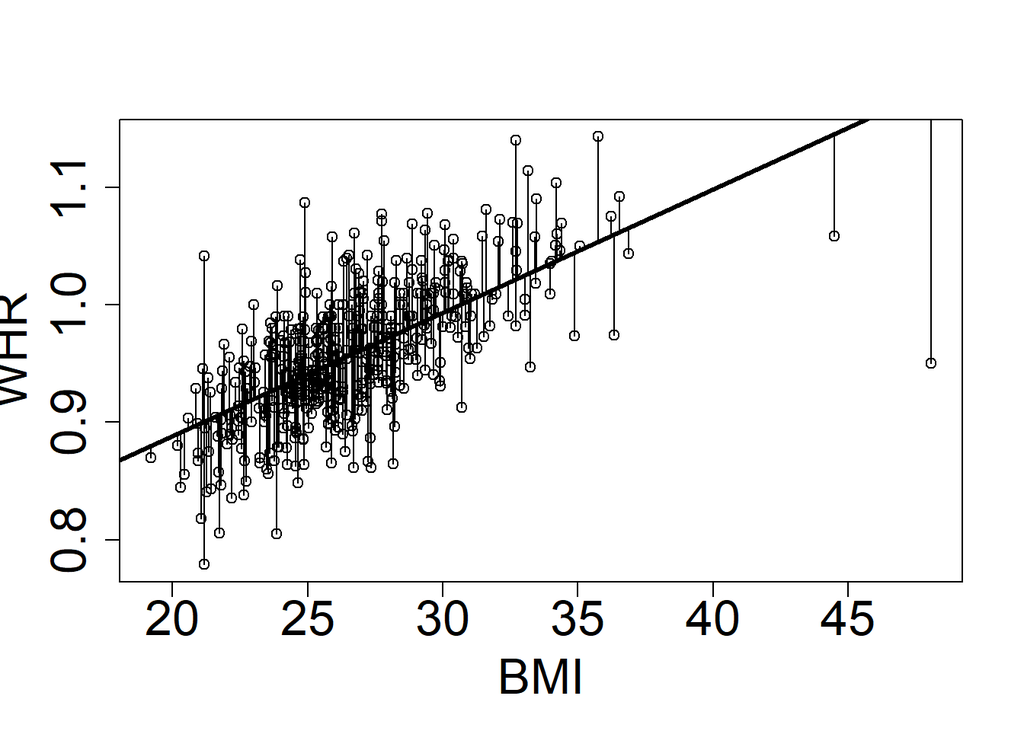

```r
plot(BMI, WHR, cex.lab=2, cex.axis=2, cex.main=2, pch=21)
abline(lm(WHR~BMI), lwd=3)
segments(BMI, fitted(whr.bmi), BMI, WHR)
```

```r
datTraits$WHR_BMIadj<-resid(whr.bmi)
```

Pull out eigengene expression, order by expression

```r
eigValue = eigengene[,2:435]

colnames(eigValue) = gsub("[^0-9]", "", colnames(eigValue))
eigValue = t(eigValue)

eigValues = eigValue[order(as.numeric(as.character(rownames(eigValue)))), ]
eigValues[1:5,1:5]
```

```
##             [,1]        [,2]         [,3]        [,4]        [,5]
## 369 -0.039451311  0.01621186  0.012166092  0.02689967 -0.06518181
## 377  0.008162656 -0.11668762  0.077665871 -0.06101047 -0.01494161
## 378 -0.031423708  0.04036380 -0.000127812  0.01423877 -0.01674987
## 379 -0.086357241  0.02200417 -0.019081757 -0.03109256 -0.08353708
## 420  0.050509765 -0.01700372 -0.003559246  0.12682583  0.05208071
```

Find correlation between gene expression and WHRadjBMI

```r
GS1=as.numeric(cor(datTraits$WHR_BMIadj,eigValue, use="p"))
GeneSignificance=abs(GS1)

GeneSignificance = as.data.frame(GeneSignificance)
GeneSignificance$module = eigengene$Module
```

Plot correlations

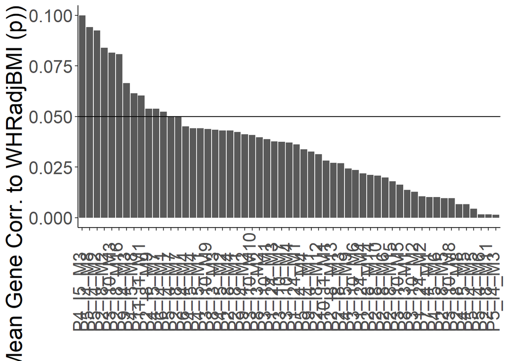

```r
corrss = ggplot(GeneSignificance[order(GeneSignificance$GeneSignificance, decreasing = T),], aes(y=GeneSignificance, x=reorder(module, -GeneSignificance)), na.rm = TRUE) +
  geom_bar(na.rm = TRUE, stat="identity")+
  theme_classic()+
  theme(text=element_text(size=22),plot.title = element_text(hjust = 0.5), axis.title.y = element_text(hjust = 1), axis.text.x = element_text(angle = 90, hjust = 0, vjust = 0.25))+
  labs(x = "",y = "Abs(Mean Gene Corr. to WHRadjBMI (p))")+
  geom_abline(intercept = 0.05, slope = 0)
plot(corrss)
```

Find GO term enrichment per module

```r
#install packages
if (!requireNamespace("BiocManager", quietly = TRUE))
  install.packages("BiocManager")
BiocManager::install()
a


if (!requireNamespace("BiocManager", quietly = TRUE))
  install.packages("BiocManager")
BiocManager::install("topGO")
a
#browseVignettes("topGO")

if (!requireNamespace("BiocManager", quietly = TRUE))
  install.packages("BiocManager")
BiocManager::install("AnnotationDbi")

a

install.packages( repos=c('http://cran.fhcrc.org/'), pkgs=c('Rcpp') )
if (!requireNamespace("BiocManager", quietly = TRUE))
  install.packages("BiocManager")
BiocManager::install("ALL")
a

if (!requireNamespace("BiocManager", quietly = TRUE))
  install.packages("BiocManager")

BiocManager::install("org.Hs.eg.db")
a

#&&&&&&&&&&&&&&&&&&&&&&&&&&&&&&&&&&&&&&
library(topGO)
library(ALL)
library(org.Hs.eg.db)
#library(org.Mm.eg.db)
#data(ALL)
#data(geneList)

#&&&&&&&&&&&&&&&&&&&&&&&&&&&&&&&&&&&& my directory
# output total gene symbols with a header
#write.table(c('geneSyms', names(datExprHuman)),file='totalGeneUniverseNames.txt',sep="",col.names=FALSE,row.names=FALSE,quote=FALSE)



# make sure your first element is not becoming the column name here
#geneNames <- read.delim('totalGeneUniverseNames.txt')
geneNames = mods$Gene[mods$Module != "UNCLASSIFIED"]
#geneNames <- names(datExprHuman) # gene universe ( all the names of the genes)
sigtotal = []

# what are the modules that you are interested in?
eigeneGrey = eigengene[eigengene$Module != "UNCLASSIFIED",]
intModules = as.character(eigeneGrey$Module)
i = 1
for (module in intModules)
{
  #fileName0 <- paste('Int-Gene-Names-', module,sep='')
  #fileName <- paste(fileName0, '.txt',sep='')
  #fileNameS <- paste(fileName0, '.csv',sep='')

  # this is the list of genes in the target module
  genesInTargetModule = mods$Gene[!is.na(match(mods$Module, eigengene$Module[i]))]
  #genesInTargetModule = kdss$V1
  # Select module probes
  myInterestingGenes <- (t(genesInTargetModule)) # int genes ( all the genes in each modules)

  geneList <- factor(as.integer(geneNames %in% myInterestingGenes))
  names(geneList) <- geneNames # gene names and 1 or 0 in their cell s

  GOdata <- new("topGOdata", ontology = "BP", allGenes = geneList, annot = annFUN.org, mapping = "org.Hs.eg.db", ID = "symbol")
  resultFisher <- runTest(GOdata, algorithm = "classic", statistic = "fisher")
  resultFisher
  allGO = usedGO(object = GOdata)
  allRes <- GenTable(GOdata, classicFisher = resultFisher,ranksOf = "classicFisher", topNodes = length(allGO))
  # get FDR
  a <- p.adjust(allRes$classicFisher, method = "fdr", n = length(allRes$classicFisher))
  allRes$classicFisher <- a
  # GO term result file
  #fileNameEx <- paste('GO_', fileNameS,sep='')
  #write.csv(allRes, file=fileNameEx,row.names=FALSE, quote = FALSE)

  sig = allRes[allRes$classicFisher <= 0.05,]
  if(nrow(sig) != 0){
    i
    sig$mod = module
    sigtotal = rbind(sigtotal, sig)
  }


  i = i+1
}
```

Select highly correlated modules. Choose modules highly correlated or enriched for adipocyte processes

```r
WGCNAgenes = mods$Gene[(mods$Module == "P7_I4_M1")
                        |(mods$Module == "P3_I10_M1")|(mods$Module == "P3_I10_M2")|
                          (mods$Module == "P2_I8_M15")|(mods$Module == "P2_I8_M11")|
                          (mods$Module == "P1_I24_M1")|(mods$Module == "P4_I5_M6")
                        |(mods$Module == "P2_I8_M7")|(mods$Module == "P8_I3_M1")|
                          (mods$Module == "P4_I5_M2")|(mods$Module == "P2_I8_M3")
                        |(mods$Module == "P4_I5_M8")|(mods$Module == "P8_I3_M2")|
                          (mods$Module == "P1_I24_M2")|(mods$Module == "P4_I5_M4")|
                          (mods$Module == "P2_I8_M16")|(mods$Module == "P2_I8_M2")|
                          (mods$Module == "P9_I4_M3")]
length(WGCNAgenes)
```

```
## [1] 6621
```

> GWAS genes and others

WHRadjBMI GWAS genes were determined by two methods: 1. Nearest gene in haploreg:

```r
nearestBFD = read.csv("haploregNear.csv")
nearestBFD$genes[1:5]
```

```
## [1] KLF3       U6         NUP88      MFAP3      AF064858.6
## 536 Levels:  LA16c-390H2.4  TTC26 4.5kb 5' of RP11-469N6.1 ... ZSWIM6
```

2. Colocalized genes from Raulerson et al:

```r
colocBFD = read.table("WHRadjBMI Loci with cis-QTLs and their eSNPs_updated_12-19-18.txt")
colocBFD$gene_symbol[1:5]
```

```
## [1] OLA1   LMOD1  GGNBP2 KLC1   UBE2R2
## 42 Levels: ANKRD28 ATXN2L BPTF C17orf58 C18orf8 C1QTNF4 CARF CCDC57 ... YWHAZ
```

3. Genes downstream of KLF14, ZNF800 from Civelek et al

```r
klf14net = read.table("klf14network.txt")
adiposeGenes = read.table("adiposeSpecific.txt")
```

Combine into total geneset

```r
unionBFD = unique(c(as.character(WGCNAgenes), as.character(t(adiposeGenes)), as.character(nearestBFD$genes),as.character(t(klf14net)), as.character(colocBFD$gene_symbol)))
geneExp = processed[!is.na(match(row.names(processed),unionBFD)),]
```

> CIT priors

Add gene -> gene pairs directly to network by using the causal inference test. If snp 1 -cisQTL-> gene A, and snp 1 -transQTL-> gene B, is the snp action on gene B mediated through gene A (snp 1 -> gene A -> gene B). You will need genotype data, cis-eQTLs fr each gene, and trans-eQTLs for each gene.

Since this takes a lot of time an memory to run, it was necessary to run as two different sets.

```r
library(ggplot2)
library(RODBC)
library(plyr)
library(dplyr)
#setwd('G:/Mete/METSIM1400/eQTLs')

# cis: 1Mb upstream/downstream, 1.43e-4
# trans: 3.7e-8


ch = odbcDriverConnect('SERVER=10.14.48.13;DATABASE=Human;DRIVER={ODBC Driver 13 for SQL Server};Trusted_Connection=Yes')

offsets = sqlQuery(ch, 'select * from Support.ChromosomeOffsets_hg19', stringsAsFactors=F)
rownames(offsets) = offsets$chr

offset2 = sort(offsets$offset)
midpoints = (offset2[2:24] + offset2[1:23])/2
chr_labels = c(as.character(1:22), 'X')
rect_bounds = data.frame(lower=offset2[0:11*2+1], upper=offset2[1:12*2])


# 1% FDR adipose cutoffs
trans_cutoff = 1e-4
cis_cutoff = 2.46e-4
q = sprintf('select gene_symbol, gene_chr, gene_start_bp, gene_end_bp, gene_start_abs, gene_end_abs, rsID, snp_chr, snp_bp_hg19, snp_bp_abs, pvalue
            from [expressionQTL].[METSIM770_Adipose_k35_PEER_corrected_residuals_invnorm_fastlmm_nounitvar_nozeromean_cis_for_SMR_AllInfo]
            where pvalue < %g and not (snp_chr = gene_chr and snp_bp_hg19 between gene_start_bp-1e6 and gene_end_bp+1e6)',
            trans_cutoff)

trans_qtl = sqlQuery(ch, q, stringsAsFactors = F)
trans_qtl = arrange(trans_qtl, pvalue)
write.table(trans_qtl, "trans_qtl.txt")

q = sprintf('select gene_symbol, gene_chr, gene_start_bp, gene_end_bp, gene_start_abs, gene_end_abs, rsID, snp_chr, snp_bp_hg19, snp_bp_abs, pvalue
            from [expressionQTL].[METSIM770_Adipose_k35_PEER_corrected_residuals_invnorm_fastlmm_nounitvar_nozeromean_cis_for_SMR_AllInfo]
            where pvalue < %g and (snp_chr = gene_chr and snp_bp_hg19 between gene_start_bp-1e6 and gene_end_bp+1e6)',
            cis_cutoff)

cis_qtl = sqlQuery(ch, q, stringsAsFactors = F)
cis_qtl = arrange(cis_qtl, pvalue)
write.table(cis_qtl, "cis_qtl.txt")



modQTLs = read.table("modQTLs.txt")
cis_qtl = cis_qtl[!is.na(match(cis_qtl$gene_symbol,modQTLs$probesetID)),]
trans_qtl = trans_qtl[!is.na(match(trans_qtl$gene_symbol,modQTLs$probesetID)),]
esnps = cis_qtl[!is.na(match(cis_qtl$rsID, trans_qtl$rsID)),]
bayeslist = as.data.frame(esnps$rsID)
bayeslist$cis_gene = esnps$gene_symbol
bayeslist$pval = esnps$pvalue
j = 0
for (g in bayeslist$cis_gene) {
  j = j + 1
  bayeslist$cis_color[j] = as.character(modQTLs$colr[modQTLs$probesetID == g])
}
j = 0
for (i in bayeslist$`esnps$rsID`) {
  j = j + 1
  bayeslist$trans_gene[j] = as.character(trans_qtl$gene_symbol[trans_qtl$rsID == i])
}
j = 0
for (g in bayeslist$trans_gene) {
  j = j + 1
  bayeslist$trans_color[j] = as.character(modQTLs$colr[modQTLs$probesetID == g])
}

bayes = bayeslist[(bayeslist$cis_color == bayeslist$trans_color),]

bayes1 = as.data.frame(bayes$cis_color)
colnames(bayes1) = "color"
bayes1$cis = bayes$cis_gene
bayes1$trans = bayes$trans_gene
bayes1 = unique(bayes1)
bayes1 = arrange(bayes1, color)
write.table(bayes1, "whitelist.txt")
```

Find gene -> gene pairs where both genes are present in gene set priorset.txt is equivalent to whitelist.txt

```r
CIT = read.table("priorset.txt")
CITinset = CIT[!is.na(match(CIT$V1,rownames(geneExp))),]
CITinset = CITinset[!is.na(match(CITinset$V2,rownames(geneExp))),]
CITinset[1:5,]
```

```
##      V1     V2
## 4  EDF1 C4orf3
## 5  EDF1 C4orf3
## 6 ERCC4 EXOC6B
## 7  STRN  TCEA1
## 8  STRN  TCEA1
```

> eQTL priors

Genes with cis-eQTLs are input as prior information. They were previously found in the METSIM dataset.

```r
qtlGeneset = read.table("qtlGenes.txt", header = F)

qtlsinSet = qtlGeneset[!is.na(match(qtlGeneset$V1,rownames(geneExp))),]
qtlsinSet[1:5]
```

```
## [1] PAFAH2 HNMT   NUDCD1 SVIL   NAP1L4
## 20261 Levels: 7SK A1BG-AS1 A2M A2M-AS1 A2MP1 A4GALT A4GNT AAAS AACS ... ZZZ3
```

> data discretization

Discretize gene expression data into 0,1,and 2 bins for low, medium and high expression using k-means clustering.

```r
library(arules)
discCUR =  discretizeDF(geneExp, default = list(method = "cluster", breaks = 3, labels = c("0","1", "2")))
discCUR[1:5,1:5]
```

```
##        X377 X1044 X6689 X2278 X10070
## TSPAN6    1     1     1     1      1
## DPM1      1     1     1     1      1
## SCYL3     0     0     0     0      0
## CFH       2     2     1     2      2
## GCLC      1     1     1     1      1
```

```r
geneExp[1:5,1:5]
```

```
##            X377    X1044    X6689    X2278   X10070
## TSPAN6 4.247076 4.981006 5.253577 4.850724 5.338924
## DPM1   4.435425 4.957267 5.287869 5.023942 4.969878
## SCYL3  2.156265 2.267406 2.635605 2.546329 2.473463
## CFH    5.234614 6.141455 5.581595 6.494728 6.028804
## GCLC   3.840722 4.746138 4.941729 4.978256 5.448290
```

```r
write.table(discCUR, "discCUR.txt", col.names = F, quote = F)
write.table(geneExp, "contCUR.txt", col.names = F, quote = F)
write.table(CITinset, "priorsCUR.txt", col.names =  F, quote = F, row.names = F)
write.table(qtlsinSet, "qtlsCUR.txt", col.names = F, quote = F, row.names = F)
```